# HW1 Bootstrapping

Abraham Khan

August 8, 2018

# Bootstrapping

```
## [1] "SPY" "TLT" "LQD" "EEM" "VNQ"
```

|  | SPY | TLT | LQD | EEM | VNQ |
| --- | --- | --- | --- | --- | --- |
| Average Annual Return | 10.57328 | 7.065842 | 5.343592 | 28.59331 | 10.86803 |
| Annualized Standard Deviation | 19.76460 | 14.536690 | 8.287168 | 63.89098 | 33.59584 |

The above table shows the annualized returns and standard deviation in returns of our five assets. Using these metrics as proxies for return and risk, respectively, we can their general characteristics. SPY commonly represents “the market” by indexing the US’s 500 largest stocks. Over the last eight and a half years it has returned 10% on average, but had a standard deviation of almost 20% due to sharp rises an falls. TLT and LQD are fixed income securities that offer lower returns, but much more consistent returns. Between them, the corporate bonds (LQD) show lower risk and returns, likely because the security is diversified across companies while TLT is 100% tied to the US government. In contrast, EEM represents emerging market stocks which have high potential gains, but also extremely high volatility. Lastly the real estate ETF (VNQ) returned roughly the same on average as the S&P, but with significantly higher volatility. This does not seem to follow the notion of higher risk is rewarded with higher returns……

The charts below show the simulated ending value of portolios made up of differing combinations of these five assets, starting with equal weights on each. The safer portolio is designed with the goal of reducing variance in returns and value at risk. It is invested 40% in TLT, 40% in LQD, 20% in SPY, and excludes the assets with the highest variance in returns. The aggressive portfolio attempts to meet the goal of increasing expected returns by investing 40% in SPY, 50% in EEM, 10% in VNQ, and excluding the fixed income securities.

# Equally Weighted Portfolio

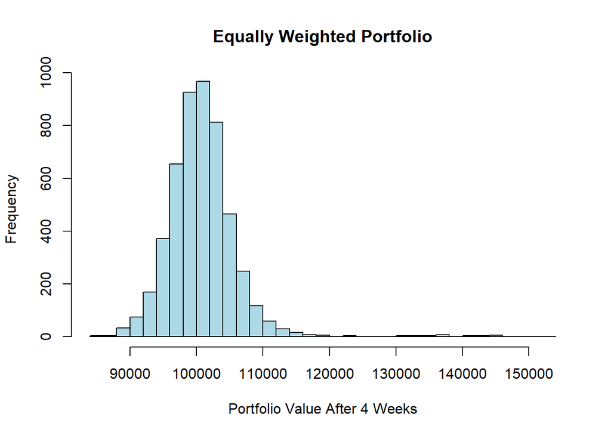

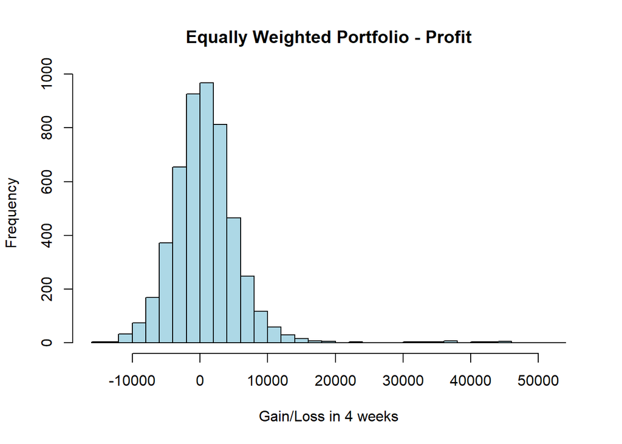

# Safe Portfolio

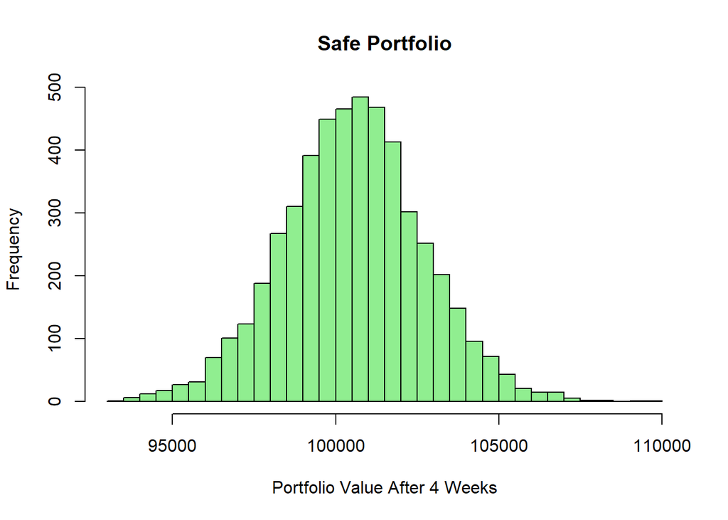

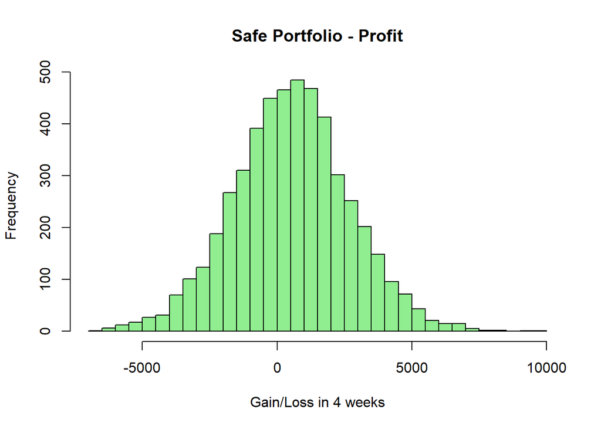

# Aggressive Portfolio

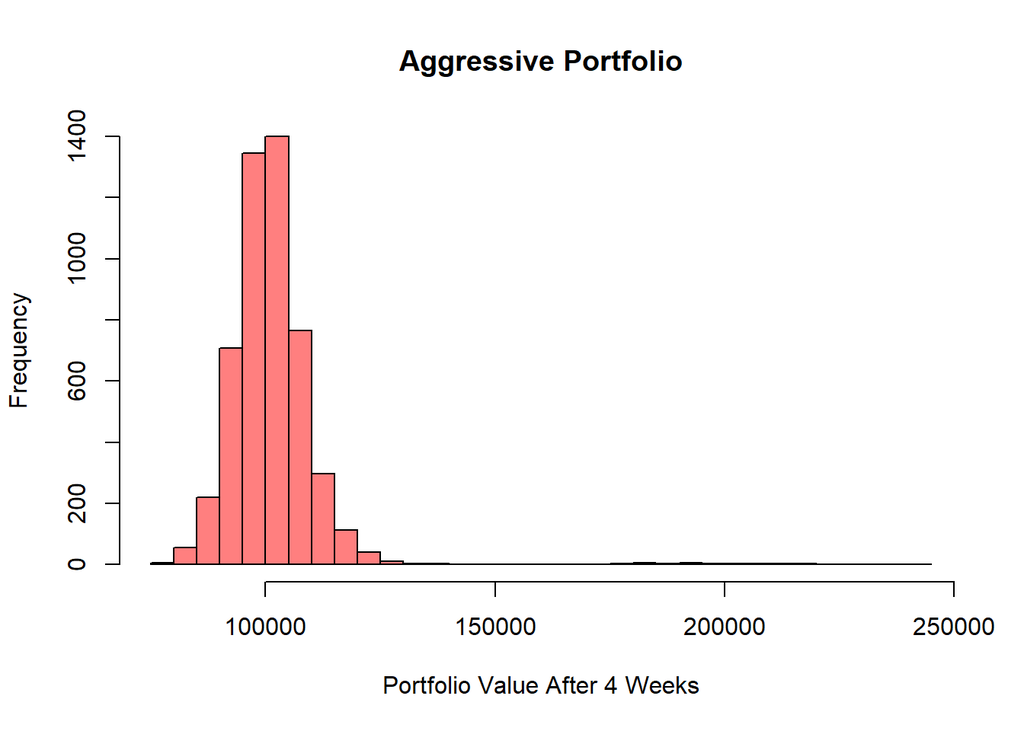

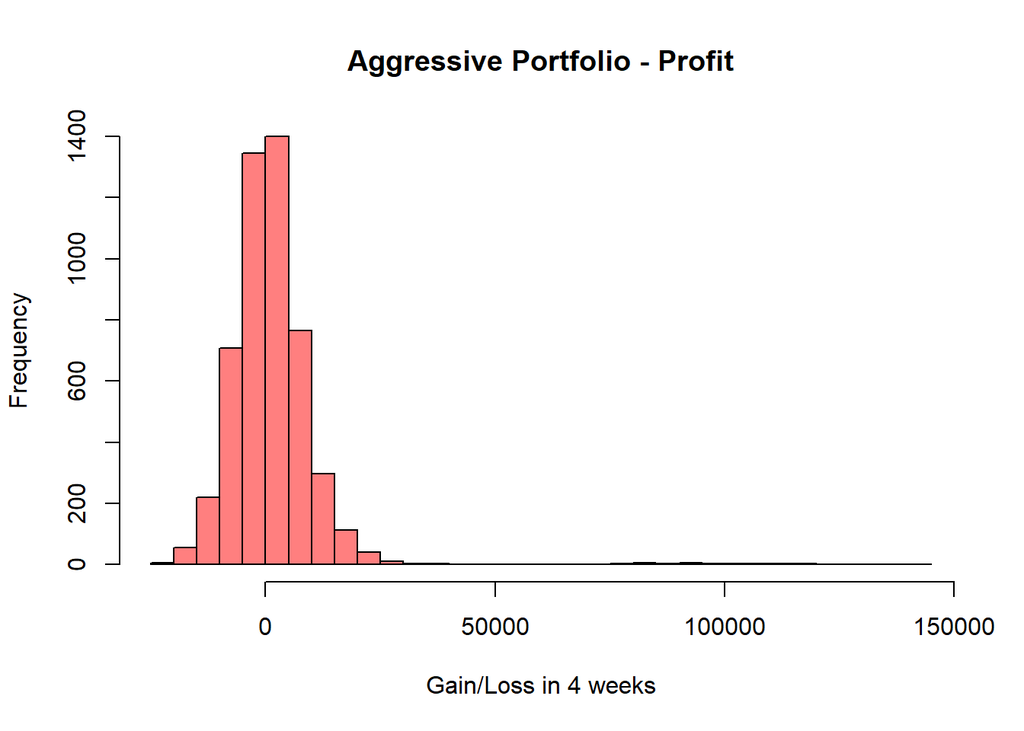

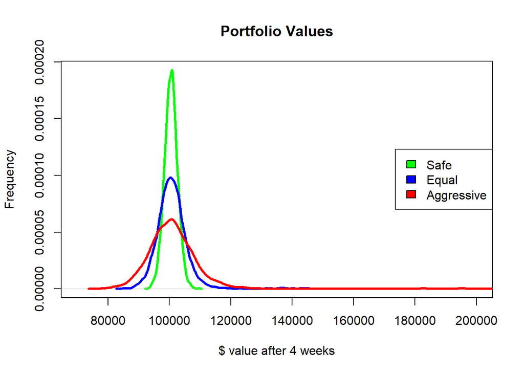

|  | Equal Weights | Safe | Aggressive |
| --- | --- | --- | --- |
| Value in 4 Weeks | 100884.037 | 100532.84 | 101391.93 |
| 5% Value at Risk | -6283.868 | -3077.27 | -10468.14 |

## Analysis

As an investor, your choice should be made depending on your risk tolerance and time horizon. A longer time frame can make use of the aggressive portfolio to achieve heigher expected returns and weather out the large variations. A shorter time frame can utilize the safer portfolio to secure a low VaR while receiving some gains.